# Midterm_Sumin Oh

Sumin Oh

2024-11-04

## 1. Import Data

```r
library(fpp2)
library(readr)
library(readxl)
library(forecast)
library(fpp)
```

```r
library(ggplot2)

sales = read.csv("https://raw.githubusercontent.com/su-min-oh/midterm/main/sales.csv",header=FALSE)

#make it a time series data
sales_ts = ts(sales$V2,start=c(2020,1),frequency=12)
```

## 2. Plot and Inference

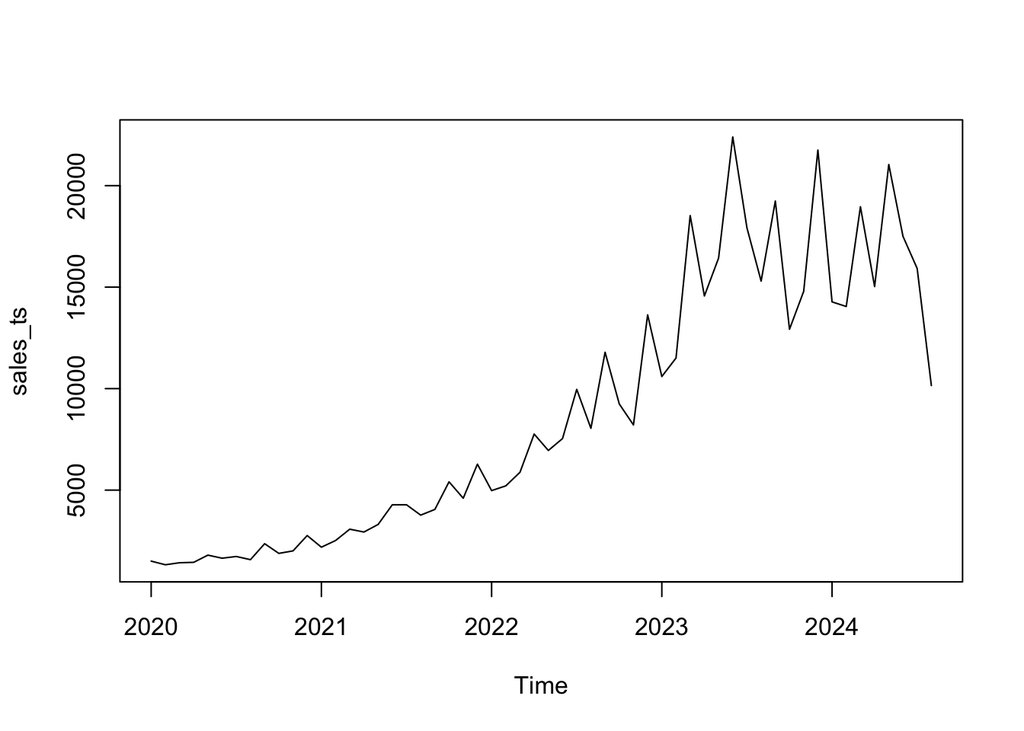

```r
plot(sales_ts)
```

#### Observation Summary

The data is about the healthcare product sales from Jan 2020 to 2024. The graph is showing gradually upward trend, however, from 2023, the upward slope is not as steep as before. Also from around 2023, there are dramatical ups and downs of the sales values. As for seasonality, I cannot conclude that it has seasonality only with this time series plot. I should do further analysis for that.

## 3. Central Tendancy

```r
#Min, max, mean, median, 1st and 3rd Quartile values
summary(sales_ts)
```

```
##    Min. 1st Qu.  Median    Mean 3rd Qu.    Max.
##    1322    2892    7246    8753   14346   22397
```

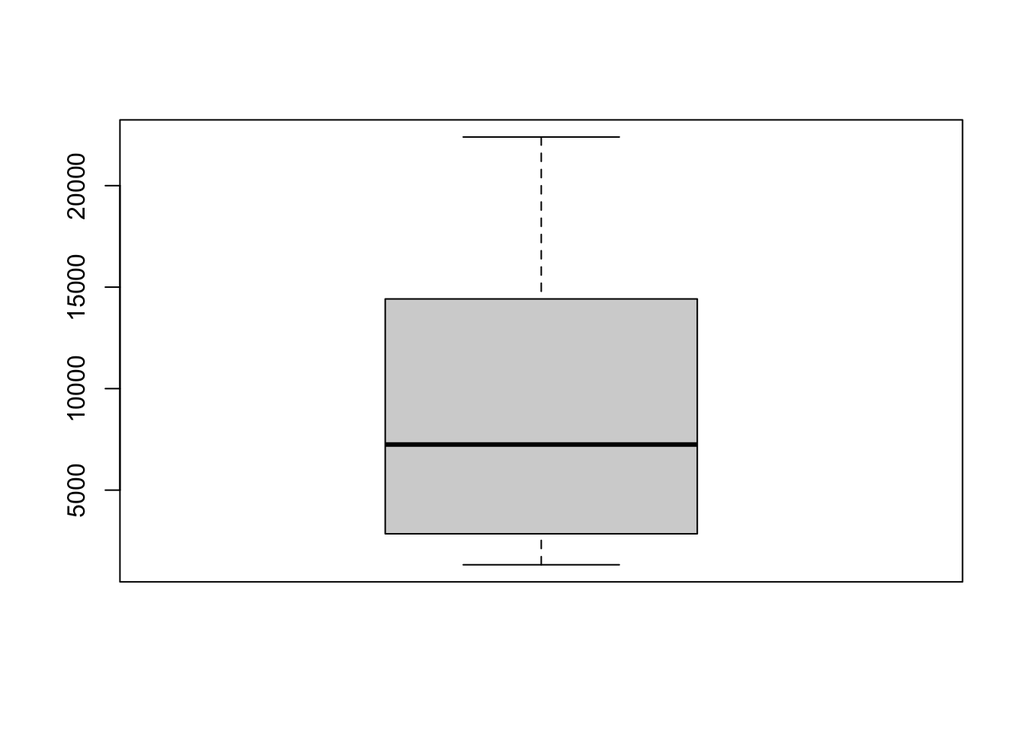

```r
#boxplot
boxplot(sales_ts)
```

#### Observation Summary

1. The maximum value is more than 20k, while minimum is only around 1k. This indicates that the data range is pretty broad.
2. Mean is greater than Median, and it means that there is a possibility that the data is skewed to the right side. This again means that most of the data is distributed on the smaller side, while big values can be found only in special cases.
3. Considering that 3rd quartile is 14346 and 1st quartile is 2892, IQR is 11454.
4. By looking at the boxplot, we can see that data is slightly right skewed as upper whisker is longer than the lower one. The absence of outliers indicates that while there is some skewness, the data is not heavily skewed, showing a moderately balanced distribution.

## 4. Decomposition

```r
sales_ts_decomp = decompose(sales_ts)
sales_ts_decomp
```

```
## $x
##            Jan       Feb       Mar       Apr       May       Jun       Jul
## 2020  1501.807  1322.171  1421.890  1442.255  1796.599  1645.273  1730.496
## 2021  2187.776  2516.465  3074.758  2935.068  3308.166  4278.035  4278.035
## 2022  4975.630  5209.274  5878.250  7761.703  6952.537  7539.993  9963.979
## 2023 10595.275 11508.050 18523.723 14564.757 16429.514 22396.778 17920.701
## 2024 14272.846 14045.829 18958.669 15027.849 21039.214 17503.115 15919.392
##            Aug       Sep       Oct       Nov       Dec
## 2020  1574.092  2360.148  1883.035  2005.627  2761.956
## 2021  3767.314  4047.972  5408.476  4599.731  6278.819
## 2022  8044.484 11791.138  9245.218  8209.193 13634.657
## 2023 15296.844 19240.256 12924.107 14791.660 21750.222
## 2024 10151.933
##
## $seasonal
##              Jan         Feb         Mar         Apr         May         Jun
## 2020 -1637.61383 -1562.74459  1068.72820   -57.46680    87.83035  2154.71713
## 2021 -1637.61383 -1562.74459  1068.72820   -57.46680    87.83035  2154.71713
## 2022 -1637.61383 -1562.74459  1068.72820   -57.46680    87.83035  2154.71713
## 2023 -1637.61383 -1562.74459  1068.72820   -57.46680    87.83035  2154.71713
## 2024 -1637.61383 -1562.74459  1068.72820   -57.46680    87.83035  2154.71713
##              Jul         Aug         Sep         Oct         Nov         Dec
## 2020   753.35870  -814.83057  1059.15192 -1259.70934 -1565.32609  1773.90491
## 2021   753.35870  -814.83057  1059.15192 -1259.70934 -1565.32609  1773.90491
## 2022   753.35870  -814.83057  1059.15192 -1259.70934 -1565.32609  1773.90491
## 2023   753.35870  -814.83057  1059.15192 -1259.70934 -1565.32609  1773.90491
## 2024   753.35870  -814.83057
##
## $trend
##            Jan       Feb       Mar       Apr       May       Jun       Jul
## 2020        NA        NA        NA        NA        NA        NA  1815.695
## 2021  2657.450  2854.981  3016.692  3233.911  3488.892  3743.516  4006.212
## 2022  5795.059  6210.189  6711.036  7193.532  7503.791  7960.678  8501.323
## 2023 13240.427 13874.139 14486.701 14950.368 15377.924 15990.342 16481.723
## 2024 16814.222 16516.462        NA        NA        NA        NA        NA
##            Aug       Sep       Oct       Nov       Dec
## 2020  1894.039  2012.671  2143.741  2268.923  2441.604
## 2021  4234.573  4463.585  4781.507  5134.466  5422.230
## 2022  8997.924  9787.268 10597.623 11275.958 12289.865
## 2023 16740.696 16864.559 16901.978 17113.344 17101.512
```

[output cut: 10 more lines]

```
## 2020  -838.55722   494.88376  -711.67402   999.00415  1302.02936 -1453.55205
## 2021  -481.53526   347.57157 -1474.76490  1886.67794  1030.59117  -917.31597
## 2022   709.29751  -138.60962   944.71866   -92.69589 -1501.43829  -429.11201
## 2023   685.61995  -629.02072  1316.54525 -2718.16121  -756.35725  2874.80503
## 2024          NA          NA
##
## $figure
##  [1] -1637.61383 -1562.74459  1068.72820   -57.46680    87.83035  2154.71713
##  [7]   753.35870  -814.83057  1059.15192 -1259.70934 -1565.32609  1773.90491
##
## $type
## [1] "additive"
##
## attr(,"class")
## [1] "decomposed.ts"
```

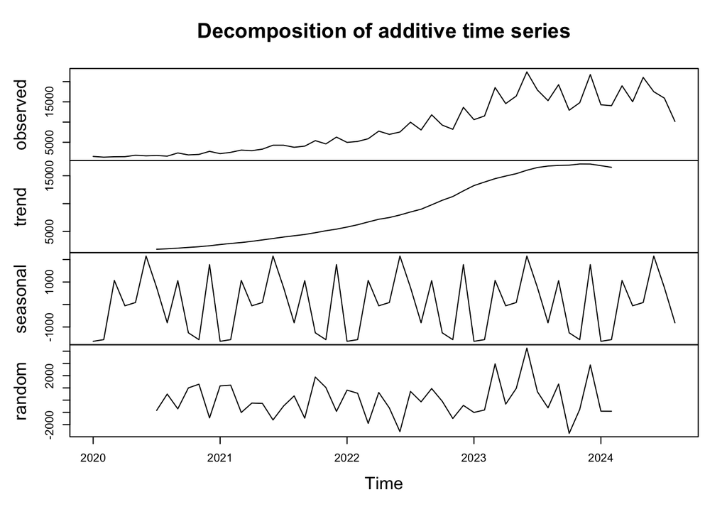

```r
plot(sales_ts_decomp)
```

- Is the time series seasonal? : From the decomposition plot, I can observe that there is a repeated figure in a regular interval of 1 year. So from this point, I can say that this time series data is seasonal.
- The decomposition is “Additive”. the decompose() function automatically decided whether to choose additive or multiplicative. The fact that it chose additive means that this data changes in regular pattern and volatility is constant.
- Seasonal indices : can be found in above, in $figure.
- The lowest month : January / The highest month : June The reasons behind it can be assumed. I have no idea which drug it is, but one assumption that I can do is that this is a drug that treating insect bites. With this scenario, sales in January, which is the coldest months of the year, will be lower than usual, while sales in June will be the highest with increased outdoor activities. Other than this, I can also assume that this is a kind of health supplements such as vitamins. People will consume this in preparation for the summer vacation, and in January, since many people catches cold, the demand for supplements may decrease as people take prescribed cold medicine instead.

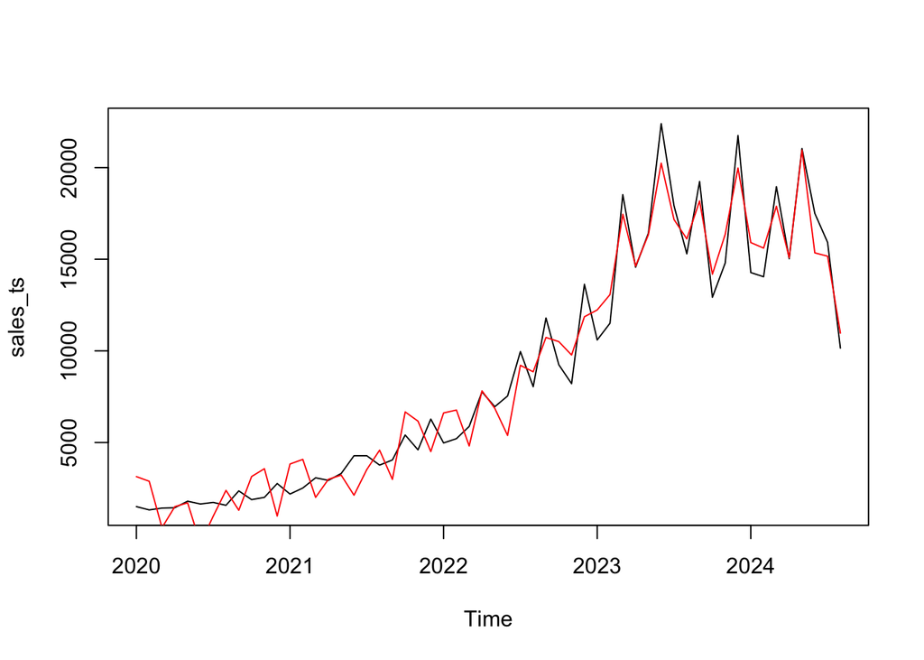

```r
# Plot for time series adjusted for seasonality
sales_seasadj = seasadj(sales_ts_decomp)
plot(sales_ts)
lines(sales_seasadj,col="red")
```

- I can see there is a considerable gap between the actual time series and the seasonally adjusted time series line, which indicates that seasonality has a substantial impact on the time series. We can conclude that seasonality have big fluctuations in the value of time series.

## 5. Naive Method

```r
#Output
sales_naive = naive(sales_ts)
sales_naive
```

```
##          Point Forecast      Lo 80    Hi 80      Lo 95    Hi 95
## Sep 2024       10151.93  6269.4469 14034.42  4214.1830 16089.68
## Oct 2024       10151.93  4661.2686 15642.60  1754.6864 18549.18
## Nov 2024       10151.93  3427.2699 16876.60  -132.5517 20436.42
## Dec 2024       10151.93  2386.9609 17916.91 -1723.5671 22027.43
## Jan 2025       10151.93  1470.4302 18833.44 -3125.2797 23429.15
## Feb 2025       10151.93   641.8232 19662.04 -4392.5248 24696.39
## Mar 2025       10151.93  -120.1596 20424.03 -5557.8769 25861.74
## Apr 2025       10151.93  -829.3959 21133.26 -6642.5603 26946.43
## May 2025       10151.93 -1495.5252 21799.39 -7661.3171 27965.18
## Jun 2025       10151.93 -2125.5659 22429.43 -8624.8813 28928.75
```

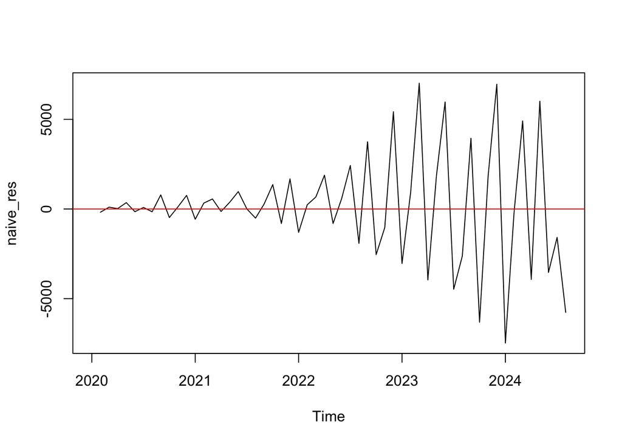

```r
#Residual Analysis
naive_res = residuals(sales_naive)

#Plot of residuals
plot(naive_res)
abline(h=0, col="red")
```

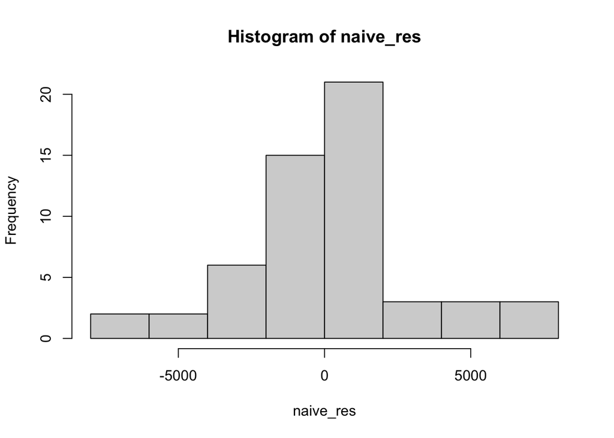

```r
#Histogram of Residuals
hist(naive_res)
```

- This shows that the residuals are quite normally distributed, and it indicates that the model’s prediction error is not biased in any particular direction.

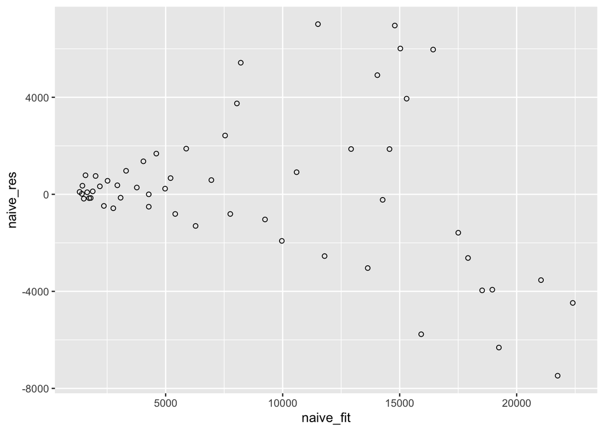

```r
#Plot of fitted vs. residuals
naive_fit = fitted(sales_naive)
ggplot(data = data.frame(naive_fit, naive_res), aes(x = naive_fit, y = naive_res)) +
  geom_point(shape = 1)
```

- Although the residuals are distributed around 0, as the fitted value increases, the variability of the residuals increases and they tend to be skewed downward. Although naive models make stable predictions for small values in the data, they tend to have poor prediction accuracy for large values.

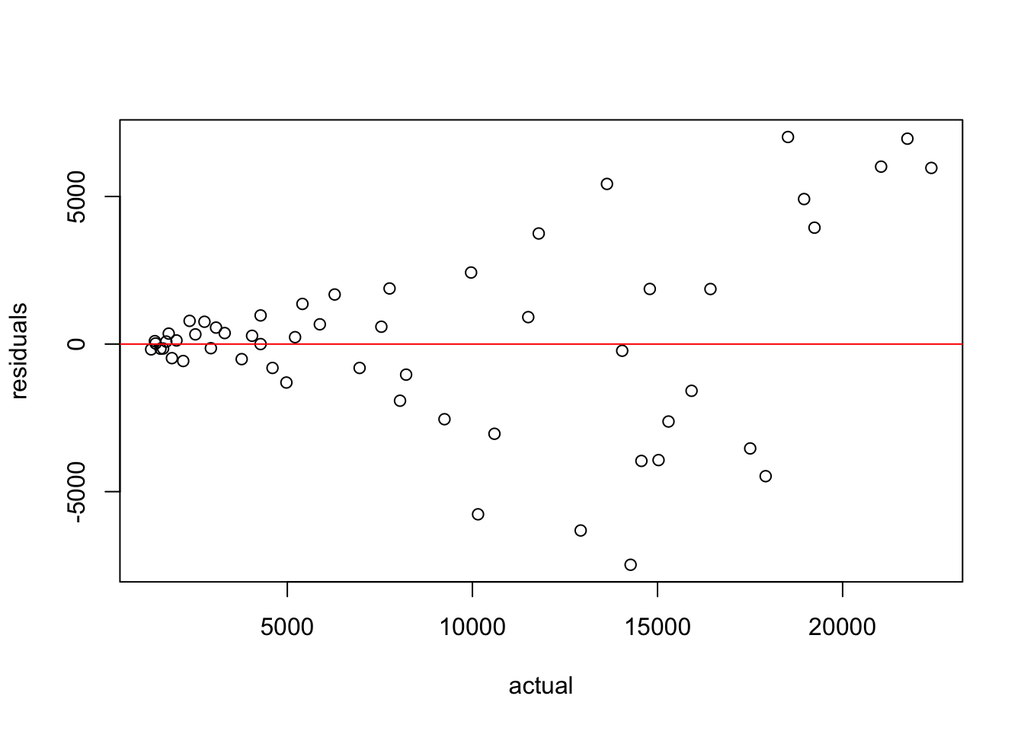

```r
#Plot of actual vs. residuals
plot(as.numeric(sales_ts),naive_res, xlab="actual",ylab="residuals")
abline(h=0,col="red")
```

- This shows that there is no pattern of residuals. However, as the actual value increases, the variance of the residuals tends to increase, meaning that this model is not able to provide accurate prediction for the big values.

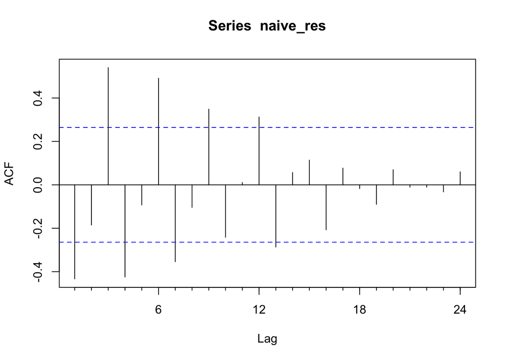

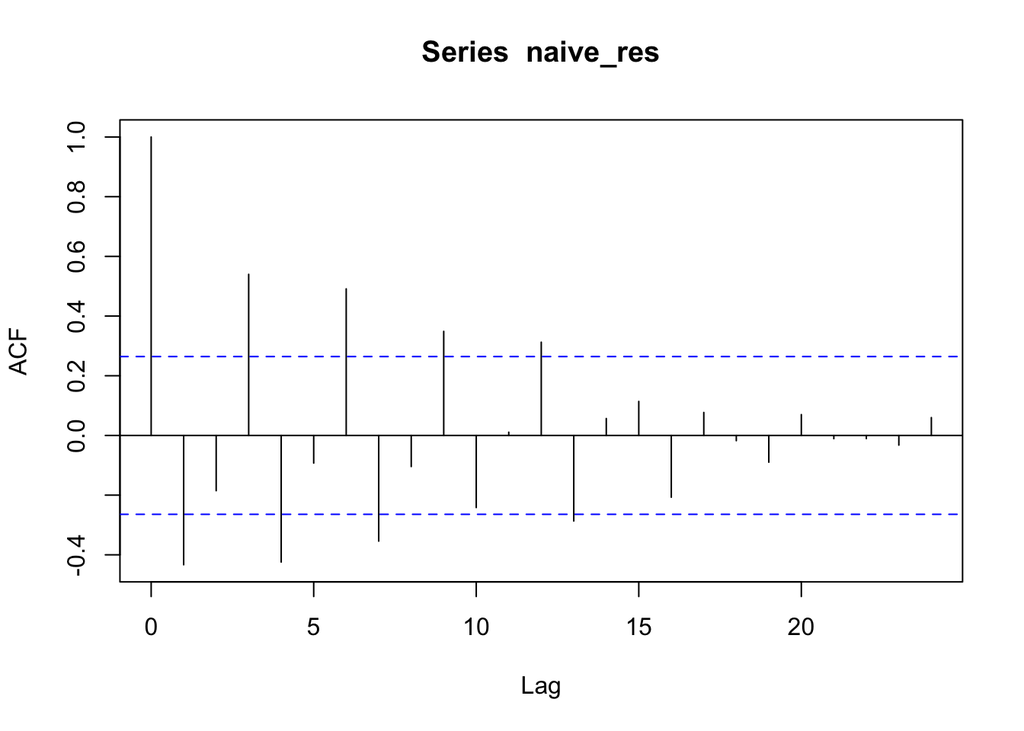

```r
#Acf
plot(Acf(naive_res))
```

- At some lags, the ACF exceeds the confidence interval, for example, at lags 1, 3, 4, 6, and 7. This suggests that there are significant correlations between residuals at these lags, which indicates that the model does not fully capture all the underlying patterns in the data. This implies that the model may not be accurately reflecting seasonal or trend factors, which could be why its predictions are not accurate enough.

```r
#Measures of accuracy
accuracy(sales_naive)
```

```
##                   ME    RMSE      MAE       MPE     MAPE      MASE      ACF1
## Training set 157.275 3029.52 2104.495 0.6371928 20.12969 0.4670533 -0.433312
```

```r
#Forecast for next year (table, plot)
naive_fc = naive(sales_ts,h=12)
naive_fc
```

```
##          Point Forecast      Lo 80    Hi 80       Lo 95    Hi 95
## Sep 2024       10151.93  6269.4469 14034.42   4214.1830 16089.68
## Oct 2024       10151.93  4661.2686 15642.60   1754.6864 18549.18
## Nov 2024       10151.93  3427.2699 16876.60   -132.5517 20436.42
## Dec 2024       10151.93  2386.9609 17916.91  -1723.5671 22027.43
## Jan 2025       10151.93  1470.4302 18833.44  -3125.2797 23429.15
## Feb 2025       10151.93   641.8232 19662.04  -4392.5248 24696.39
## Mar 2025       10151.93  -120.1596 20424.03  -5557.8769 25861.74
## Apr 2025       10151.93  -829.3959 21133.26  -6642.5603 26946.43
## May 2025       10151.93 -1495.5252 21799.39  -7661.3171 27965.18
## Jun 2025       10151.93 -2125.5659 22429.43  -8624.8813 28928.75
## Jul 2025       10151.93 -2724.8165 23028.68  -9541.3560 29845.22
## Aug 2025       10151.93 -3297.3932 23601.26 -10417.0365 30720.90
```

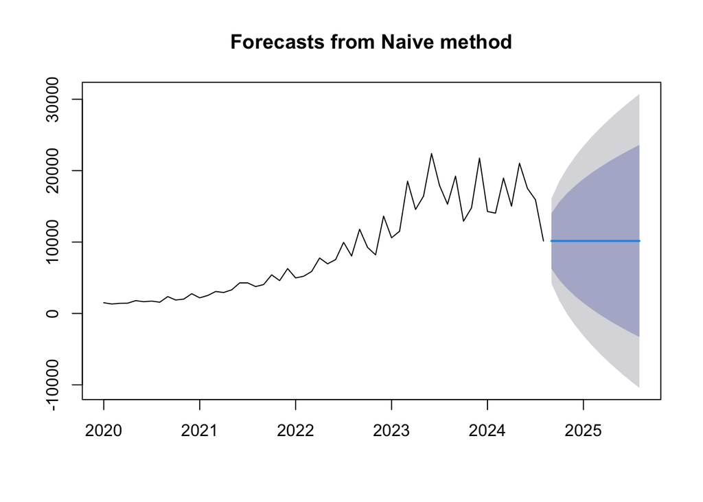

```r
plot(naive_fc)
```

#### Summary of this forecasting technique

- I forecasted for next 12 months
- How good is the accuracy? : For now, it’s hard to measure it’s accuracy since I haven’t done the accuracy test for other forecast models. Just to assume with the values of MAPE, the absolute percentage error is about 20%, which is very big, so this method seems to be not accurate. But still, it needs to be compared with other models later on.
- Predicted value : By checking the table, it predicts the value of the time series to be 10151.93 for the forecast period. This is the value of the last data from the given datset.

## 6. Simple Moving Averages

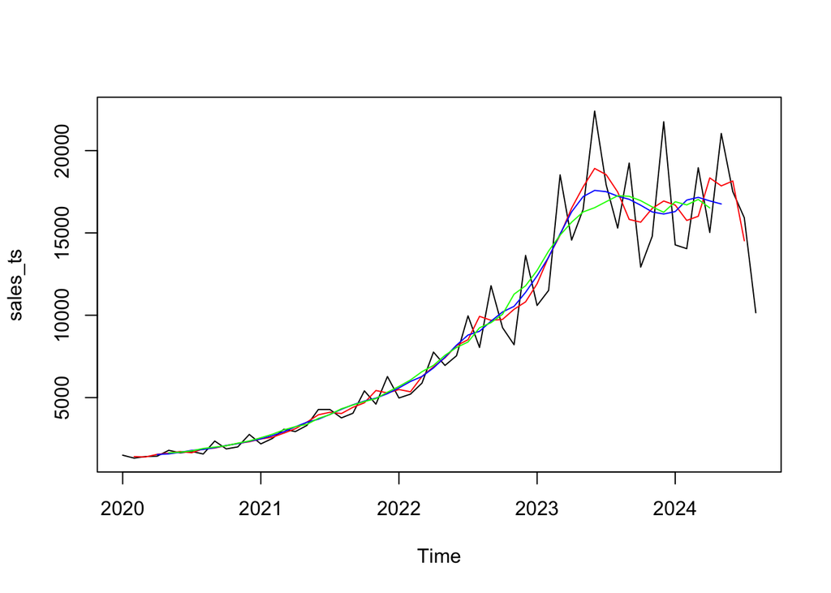

```r
MA3 = ma(sales_ts, order=3)
MA6 = ma(sales_ts, order=6)
MA9 = ma(sales_ts, order=9)

plot(sales_ts)
lines(MA3,col="red")
lines(MA6,col="blue")
lines(MA9,col="green")
```

```r
#Forecast for the next 12 months using the best one
MA9_fc = forecast(MA9,h=12)
```

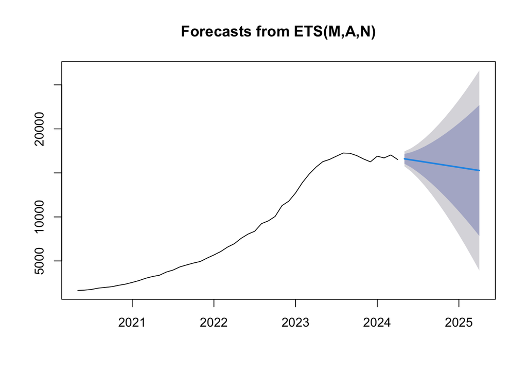

```r
plot(MA9_fc)
```

- Observations of plots as moving average goes up : In the plot, as moving average goes up, the line becomes smoother. If you see the green line, it’s the most smooth one. As the period we reflect becomes larger, short term noise is mitigated and long term trend tends to be shown. Also, as the moving average goes up, reflection to the latest data becomes slower. So it can show the long term trend of the data well.
- (bonus) : I used order 9 to forecast for next 12 month. The reason being, I see there was a drastic drop in sales at the end of the data. So if I forecast only with recent datas such as 3 or 6 months, it will show the values to be keep decrease for the next 12 months. So I used the data from formal 9 months, to reflect general trend of this sales data.

## 7. Simple Smoothing

```r
#Simple smoothing for next 12 months
sales_ets = ets(sales_ts,model="ANN")
sales_ets_fc = forecast(sales_ets,h=12)
summary(sales_ets_fc)
```

```
##
## Forecast method: ETS(A,N,N)
##
## Model Information:
## ETS(A,N,N)
##
## Call:
## ets(y = sales_ts, model = "ANN")
##
##   Smoothing parameters:
##     alpha = 0.432
##
##   Initial states:
##     l = 1709.6741
##
##   sigma:  2603.4
##
##      AIC     AICc      BIC
## 1110.215 1110.677 1116.291
##
## Error measures:
##                    ME     RMSE      MAE      MPE     MAPE      MASE       ACF1
## Training set 511.1357 2556.488 1614.069 5.082428 15.91075 0.3582125 -0.1432659
##
## Forecasts:
##          Point Forecast     Lo 80    Hi 80    Lo 95    Hi 95
## Sep 2024       14074.56 10738.171 17410.95 8971.992 19177.13
## Oct 2024       14074.56 10440.179 17708.95 8516.252 19632.87
## Nov 2024       14074.56 10164.833 17984.29 8095.148 20053.98
## Dec 2024       14074.56  9907.643 18241.48 7701.809 20447.32
## Jan 2025       14074.56  9665.430 18483.69 7331.376 20817.75
## Feb 2025       14074.56  9435.846 18713.28 6980.258 21168.87
## Mar 2025       14074.56  9217.102 18932.02 6645.717 21503.41
## Apr 2025       14074.56  9007.792 19141.33 6325.606 21823.52
## May 2025       14074.56  8806.793 19342.33 6018.204 22130.92
## Jun 2025       14074.56  8613.186 19535.94 5722.108 22427.02
## Jul 2025       14074.56  8426.211 19722.91 5436.155 22712.97
## Aug 2025       14074.56  8245.231 19903.89 5159.369 22989.76
```

- Here I used ets model and set the model to “ANN”, which stands for additive error, no trend, no seasonality.
- alpha is 0.432, which is in the middle of 0 and 1. This model makes predictions by balancing recent and historical data, which is a setting that makes it somewhat sensitive to current data.
- The value of initial state is 1709.6741, and it represents the initial value when the data starts prediction.
- The value of sigma is 2603.4. It stands for the standard deviation of residuals. The smaller the value, the more accurate the prediction. value of 2603.4 may mean that the model fits the data fairly consistently, but not perfectly.

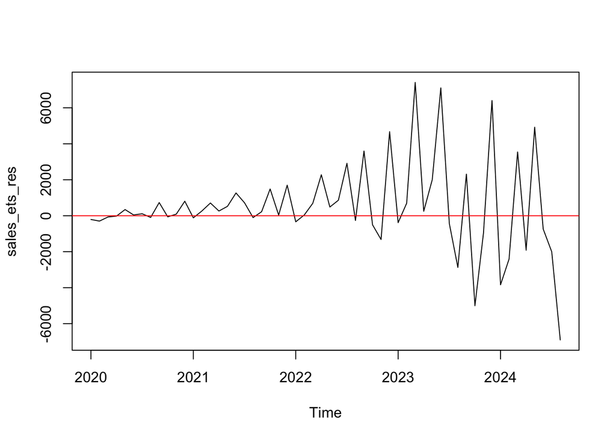

```r
#Residual Analysis
sales_ets_res = residuals(sales_ets_fc)

#Plot of residuals
plot(sales_ets_res)
abline(h=0,col="red")
```

- Similar to the ones in naive forecast, as the time goes, size of the residuals become larger. As we checked from the decomposition part, this data has seasonality and it affects the data a lot. But this simple smoothing model just reflects level, not trend or seasonality. So this seems to be natural that residuals have this much fluctuations and gaps.

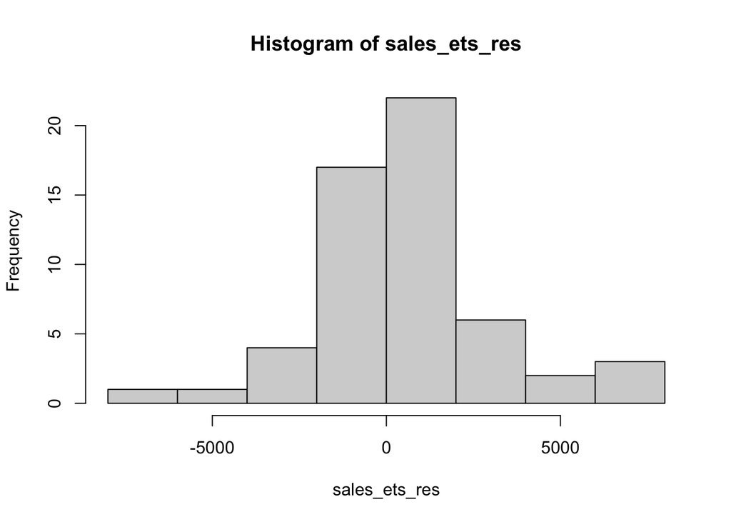

```r
#Histogram
hist(sales_ets_res)
```

- This shows that the residuals are quite normally distributed, and it indicates that the model’s prediction error is not biased in any particular direction.

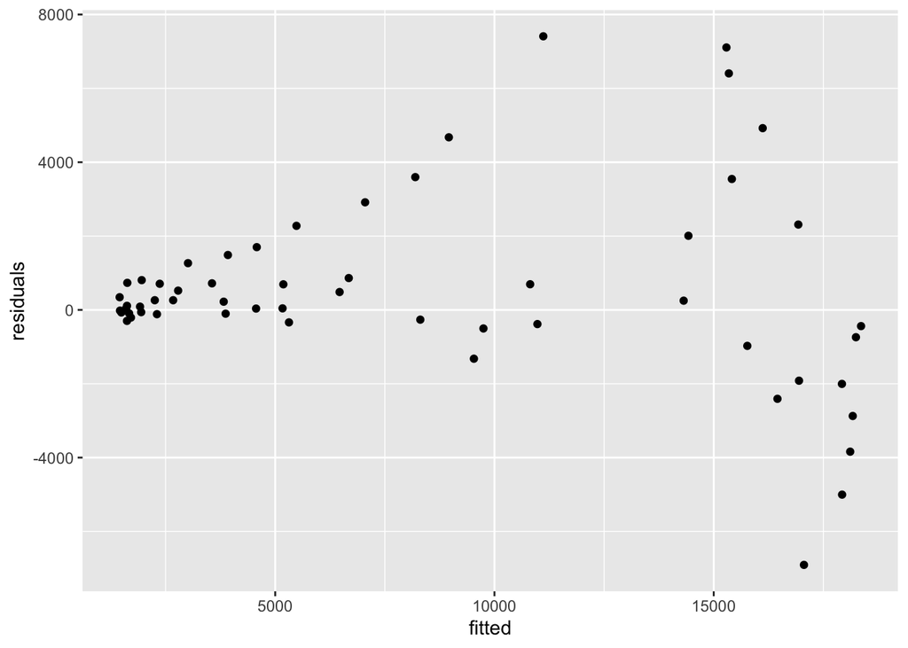

```r
#Plot of fitted vs. residuals
sales_ets_fitted = fitted(sales_ets_fc)
ggplot(data = data.frame(fitted = sales_ets_fitted, residuals = sales_ets_res),
       aes(x = fitted, y = residuals)) + geom_point()
```

- This plot shows that when the model predicts large fitted values, the variance of the residuals increases and systematic errors occur.

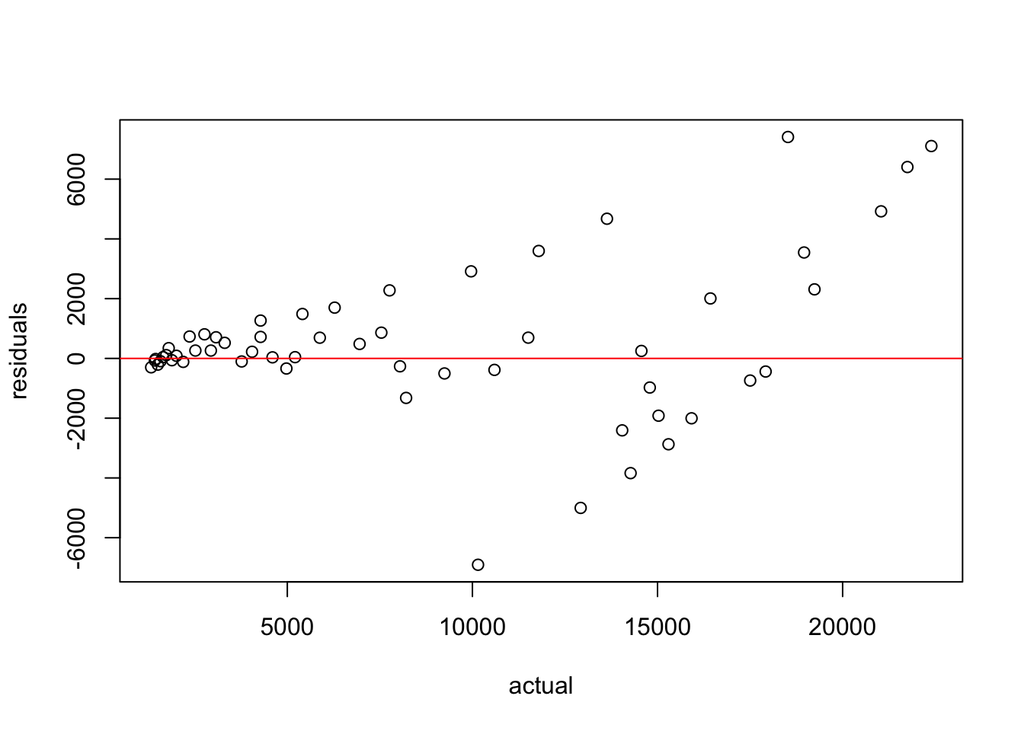

```r
#Plot of actual vs. residuals
plot(as.numeric(sales_ts),sales_ets_res, xlab="actual",ylab="residuals")
abline(h=0,col="red")
```

- This shows that there a pattern of residuals. As the actual value increases, the variance of the residuals tends to increase. The prediction model shows a stable error at small values, but the error range widens at large values. We can see that the prediction accuracy decreases depending on the size of the data.

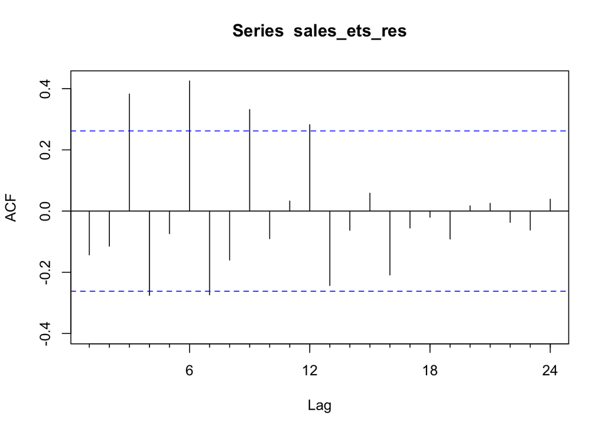

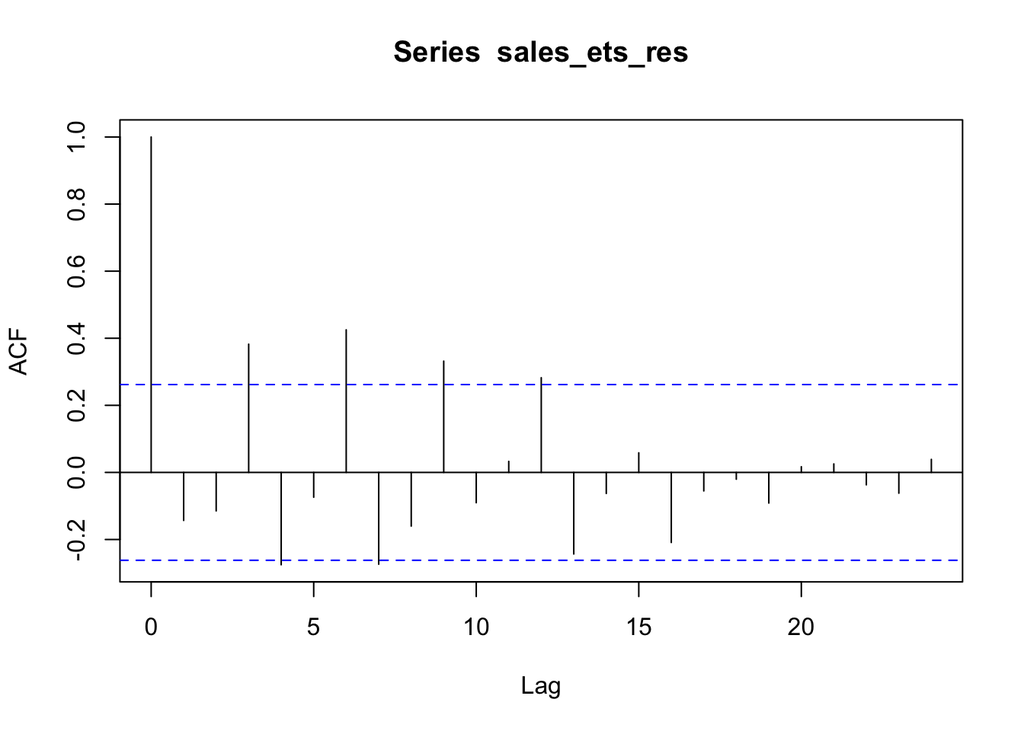

```r
#Acf
plot(Acf(sales_ets_res))
```

- There is a values that exceeds confidence interval. So we can assume that the residuals are correlated, and the model may not be predicting accurately.

```r
#Measures of accuracy
accuracy(sales_ets_fc)
```

```
##                    ME     RMSE      MAE      MPE     MAPE      MASE       ACF1
## Training set 511.1357 2556.488 1614.069 5.082428 15.91075 0.3582125 -0.1432659
```

```r
#Forecast for next year (table, plot)
sales_ets_fc
```

```
##          Point Forecast     Lo 80    Hi 80    Lo 95    Hi 95
## Sep 2024       14074.56 10738.171 17410.95 8971.992 19177.13
## Oct 2024       14074.56 10440.179 17708.95 8516.252 19632.87
## Nov 2024       14074.56 10164.833 17984.29 8095.148 20053.98
## Dec 2024       14074.56  9907.643 18241.48 7701.809 20447.32
## Jan 2025       14074.56  9665.430 18483.69 7331.376 20817.75
## Feb 2025       14074.56  9435.846 18713.28 6980.258 21168.87
## Mar 2025       14074.56  9217.102 18932.02 6645.717 21503.41
## Apr 2025       14074.56  9007.792 19141.33 6325.606 21823.52
## May 2025       14074.56  8806.793 19342.33 6018.204 22130.92
## Jun 2025       14074.56  8613.186 19535.94 5722.108 22427.02
## Jul 2025       14074.56  8426.211 19722.91 5436.155 22712.97
## Aug 2025       14074.56  8245.231 19903.89 5159.369 22989.76
```

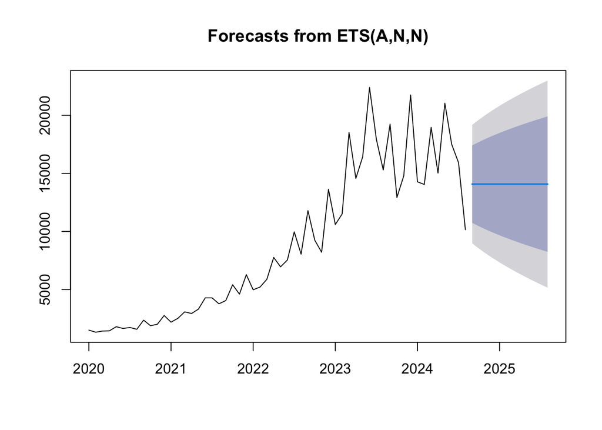

```r
plot(sales_ets_fc)
```

#### Summary of this forecasting technique

- How good is the accuracy? : Considering the MAPE of naive was 20.1269, accuracy of this simple smoothing method is better than Naive. However, Root mean squre error is about 2556. Considering the average values consisting of this data set, this error is too large. The reason for this could be that this method doesn’t reflect trend or seasonality at all.
- Predicted value : By checking the table, it predicts the value of the time series to be 14074.56 for the whole forecast period. This figure is similar to Naive method since it also shows the same value for the given period. It is because this model forecasts only based on the level of the data.

## 8. Holt-Winters

```r
#forecast for next 12 months
sales_hw = hw(sales_ts,h=12)
summary(sales_hw)
```

```
##
## Forecast method: Holt-Winters' additive method
##
## Model Information:
## Holt-Winters' additive method
##
## Call:
## hw(y = sales_ts, h = 12)
##
##   Smoothing parameters:
##     alpha = 0.3176
##     beta  = 0.0862
##     gamma = 1e-04
##
##   Initial states:
##     l = 818.4249
##     b = 343.2258
##     s = 1774.076 -1565.1 -1259.728 1059.152 -814.7662 753.5157
##            2154.785 120.2898 -57.6465 1068.374 -1562.394 -1670.559
##
##   sigma:  2428.542
##
##      AIC     AICc      BIC
## 1113.622 1129.728 1148.053
##
## Error measures:
##                     ME     RMSE      MAE       MPE     MAPE      MASE
## Training set -210.3775 2052.493 1661.449 -3.401198 33.49673 0.3687275
##                     ACF1
## Training set -0.02495954
##
## Forecasts:
##          Point Forecast      Lo 80    Hi 80      Lo 95    Hi 95
## Sep 2024      14915.453 11803.1507 18027.75 10155.5976 19675.31
## Oct 2024      11924.642  8568.2064 15281.08  6791.4168 17057.87
## Nov 2024      10947.345  7260.7678 14633.92  5309.2115 16585.48
## Dec 2024      13614.601  9515.1067 17714.09  7344.9656 19884.24
## Jan 2025       9498.231  4909.7127 14086.75  2480.6981 16515.76
## Feb 2025       8934.255  3788.3217 14080.19  1064.2291 16804.28
## Mar 2025      10892.902  5128.5202 16657.28  2077.0406 19708.76
## Apr 2025       9094.772  2657.3234 15532.22  -750.4562 18940.00
## May 2025       8601.422  1441.6443 15761.20 -2348.5131 19551.36
## Jun 2025       9963.072  2036.0955 17890.05 -2160.1923 22086.34
## Jul 2025       7890.275  -845.1816 16625.73 -5469.4528 21250.00
## Aug 2025       5649.690 -3932.5846 15231.97 -9005.1345 20304.52
```

- Value of alpha(level): 0.3176. An alpha value of 0.3176 means that past data carries some weight compared to recent data.
- Value of beta(trend): 0.0862, which is low. This model does not reflect drastic trend changes, but rather seeks more stable trend changes.
- Value of gamma(seasonality) : 0.0001. The model is set to be almost insensitive to seasonal changes. This may be because seasonality is not significant, or because seasonality is assumed to be constant.
- Initial state : level=818 it shows the initial level of data from the starting point of the forecast / trend=343 In a model with a trend, this initial trend value is used to start the prediction. / seasonality= See above. Indicates the initial value corresponding to each season.
- Value of sigma(standard deviations of error) : 2428.542. A smaller sigma value means that the model fits the data better, while a larger sigma value means that there is greater variation between the predicted and actual values. Compared to the sigma of simple smoothing, it’s slightly smaller, implying that this method can be more accurate than the simple smoothing.

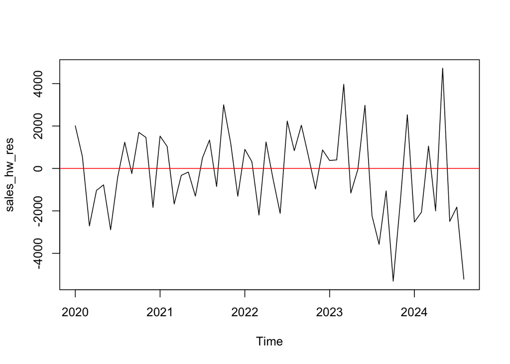

```r
#Residual Analysis
sales_hw_res = residuals(sales_hw)
#Plot
plot(sales_hw_res)
abline(h=0,col="red")
```

- The pattern is random, meaning that this model’s predictions can be seen as unbiased and stable. Also this may mean that the model reflects the level, trend, and seasonality of time series data relatively well. However, since the range of fluctuations is not completely narrow, there is a possibility that some error may occur in the prediction.

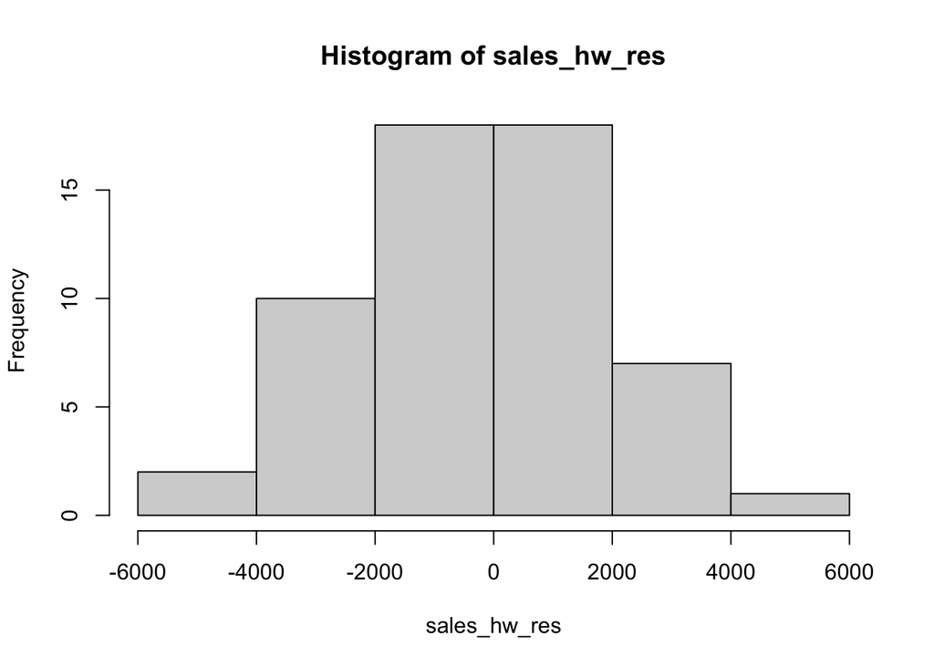

```r
#Histogram
hist(sales_hw_res)
```

- This shows that the residuals are normally distributed, and it indicates that the model’s prediction error is not biased in any particular direction.

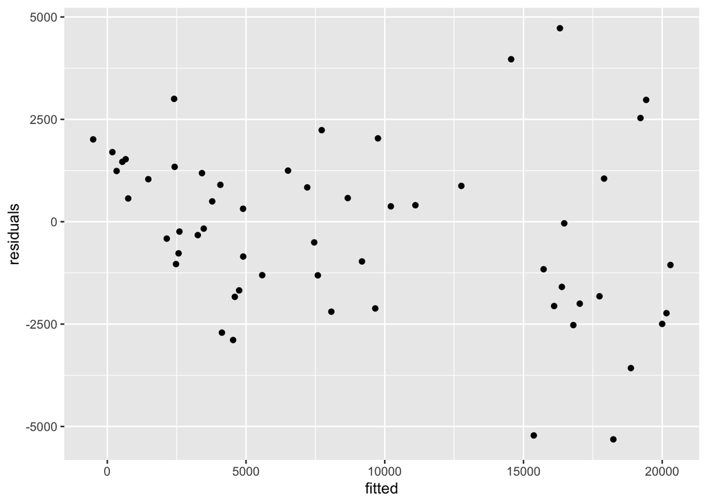

```r
#Plot of fitted vs. residuals
sales_hw_fitted = fitted(sales_hw)
ggplot(data = data.frame(fitted = sales_hw_fitted, residuals = sales_hw_res),
       aes(x = fitted, y = residuals)) + geom_point()
```

- The residuals are not evenly distributed around 0, and tend to be skewed upwards for fitted values close to 0, and the values of the residuals fluctuate greatly as the fitted value increases. This suggests that the model does not make good predictions in certain value ranges.

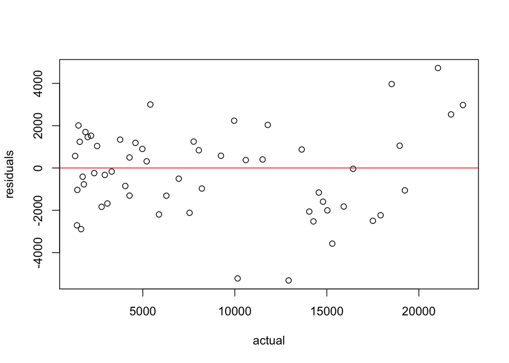

```r
#Plot of actual vs. residuals
plot(as.numeric(sales_ts),sales_hw_res, xlab="actual",ylab="residuals")
abline(h=0,col="red")
```

- Residuals are randomly distributed, meaning that there is no bias, although the range of residuals is quite large.

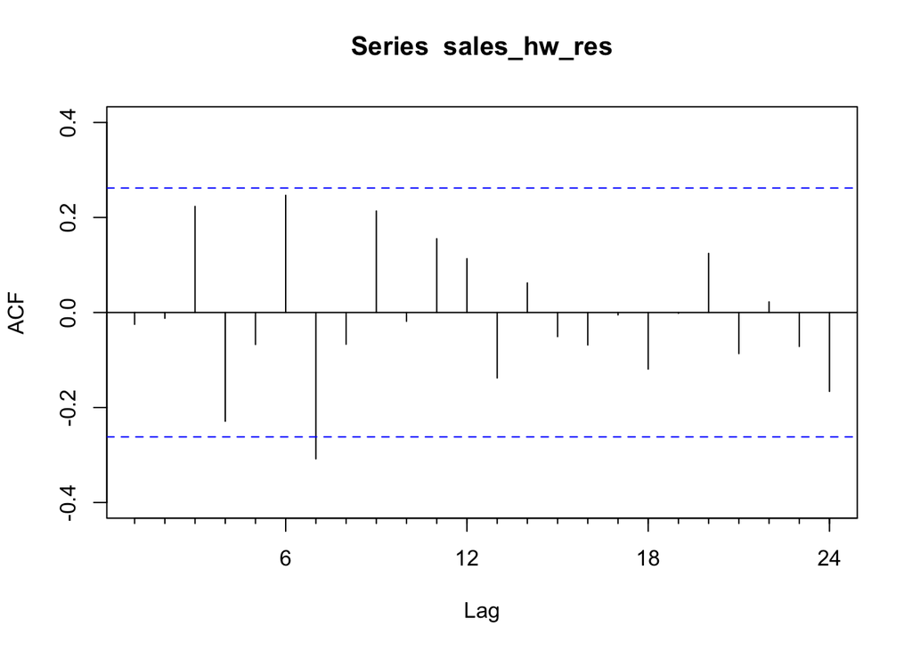

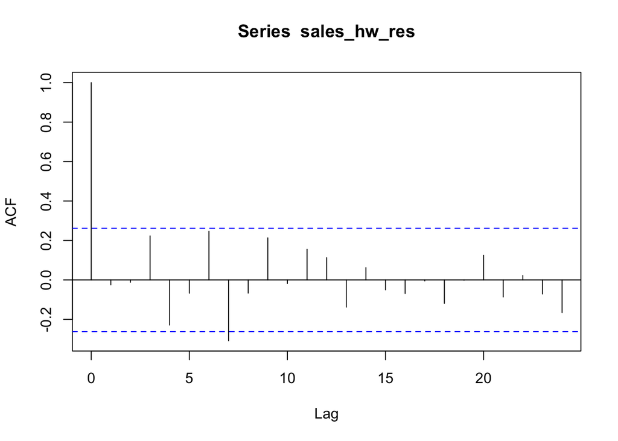

```r
#Acf
plot(Acf(sales_hw_res))
```

```r
#Measures of accuracy
accuracy(sales_hw)
```

```
##                     ME     RMSE      MAE       MPE     MAPE      MASE
## Training set -210.3775 2052.493 1661.449 -3.401198 33.49673 0.3687275
##                     ACF1
## Training set -0.02495954
```

```r
#Forecast for next year (table, plot)
sales_hw
```

```
##          Point Forecast      Lo 80    Hi 80      Lo 95    Hi 95
## Sep 2024      14915.453 11803.1507 18027.75 10155.5976 19675.31
## Oct 2024      11924.642  8568.2064 15281.08  6791.4168 17057.87
## Nov 2024      10947.345  7260.7678 14633.92  5309.2115 16585.48
## Dec 2024      13614.601  9515.1067 17714.09  7344.9656 19884.24
## Jan 2025       9498.231  4909.7127 14086.75  2480.6981 16515.76
## Feb 2025       8934.255  3788.3217 14080.19  1064.2291 16804.28
## Mar 2025      10892.902  5128.5202 16657.28  2077.0406 19708.76
## Apr 2025       9094.772  2657.3234 15532.22  -750.4562 18940.00
## May 2025       8601.422  1441.6443 15761.20 -2348.5131 19551.36
## Jun 2025       9963.072  2036.0955 17890.05 -2160.1923 22086.34
## Jul 2025       7890.275  -845.1816 16625.73 -5469.4528 21250.00
## Aug 2025       5649.690 -3932.5846 15231.97 -9005.1345 20304.52
```

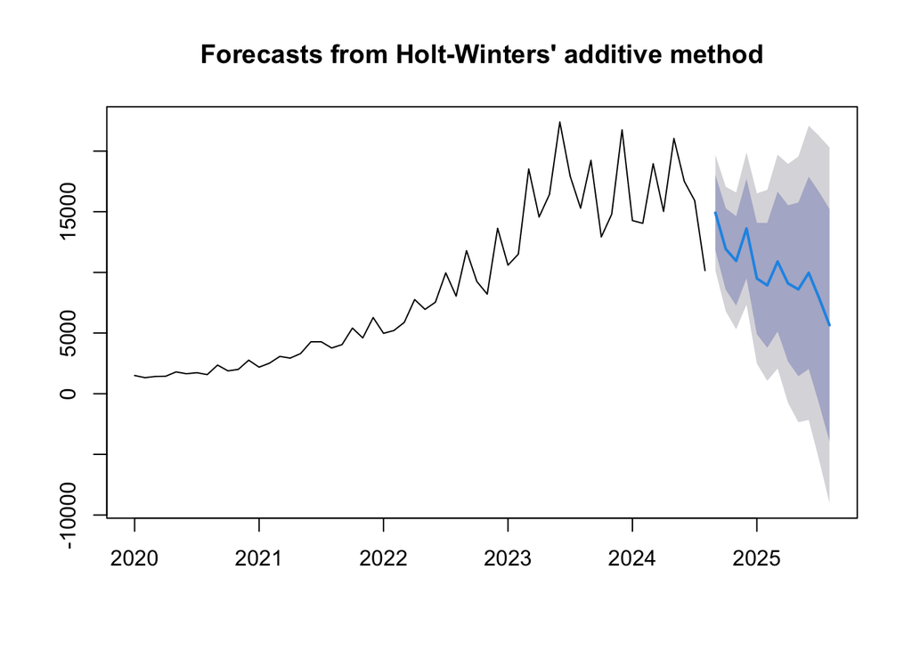

```r
plot(sales_hw)
```

#### Summary of this forecasting technique

- How good is the accuracy? : MAPE is larger than other models, while RMSE is smaller. I will further check the accuracy below for the accurate judgement.
- Predicted time series value : can be checked in the above table. Unlike Naive or simple smoothing, it has various different values for the given period.

## 9. Accuracy Summary

```r
a=accuracy(sales_naive)
b=accuracy(MA9_fc)
c=accuracy(sales_ets_fc)
d=accuracy(sales_hw)

accuracymeasure = rbind(a,b,c,d)
rownames(accuracymeasure) = c("naive","MA9","Simple smoothing","HW")

accuracymeasure
```

```
##                          ME      RMSE       MAE        MPE      MAPE       MASE
## naive             157.27502 3029.5200 2104.4945  0.6371928 20.129686 0.46705331
## MA9                -7.66315  277.9001  181.5807  0.3518105  1.989433 0.03759897
## Simple smoothing  511.13575 2556.4881 1614.0690  5.0824283 15.910753 0.35821251
## HW               -210.37750 2052.4927 1661.4486 -3.4011985 33.496728 0.36872752
##                         ACF1
## naive            -0.43331200
## MA9               0.10752017
## Simple smoothing -0.14326591
## HW               -0.02495954
```

- Naive : This is the simplest prediction method, which uses the values of the previous time point as the predicted values for the next time point. It can be useful when the data does not have a particular trend or seasonality. It has the advantage of being able to make predictions quickly.
- Moving Average : A method of forecasting using the average of data over a certain period of time. It is suitable when there is no trend and the data is relatively stable.
- Simple smoothing : A method that reflects the level of the data. This model makes predictions based on recent data, but reflects only the level of the data without trends or seasonality, so useful when there is no clear trend or seasonality in the data.
- Holt winters : A method that reflects level, trend, and seasonality. Suitable for time series data with clear trends and seasonality.
- ME (Mean Error) : This measures the overall direction of the forecast, so not suitable to evaluate the accuracy of the prediction. HW overestimates the most, and simple smoothing underestimates the value the most.
- RMSE (Root mean squire error) : Best is Moving average and worst is Naive. RMSE is a good indicator of prediction accuracy because it is more sensitive to large errors. MA9 has the smallest RMSE and is evaluated as the most accurate model.
- MAE(Mean Absolute Error) : This method gives equal importance to all errors, and the smaller the error, the more accurate it is. Best is Moving average and Worst is Naive method.
- MPE(Mean Percentage Error) : This method allows us to determine the relative error. Moving average has the smallest value, indicating that it underestimates by 0.3%. Simple smoothing, underestimates by 5% which is the largest among others.
- MAPE(Mean Absolute Percentage Error) : This shows errors as absolute percentages. Moving average is the best, while Holt-winters is the worst with the largest value.
- MASE (Mean Absolute Scaled Error) : Best is Moving average, worst is Naive
- ACF1 : Holt-Winters is evaluated as the best fitting model with the lowest lag-1 correlation, while Naive has the highest correlation.

## 10. Conclusion

- Summary of analysis : Over the analyzed period, the time series data shows a general upward/downward trend. Also it reveals a seasonal pattern that recurs regularly. I initially assumed that Holt-winters would be the best model, because the data has seasonality. However, moving average method turned out to be the best. I guess this is because the seasonality is especially strong only in certain period, so HW was not able to catch the overall changes. So in conclusion, this data doesn’t have too drastic changes and follows some regular patterns, and it makes MA the best fitting model.
- I chose to use Moving average method to forecast. With this method, the value of the time series is predicted to decrease over the next year.(Please refer to the above) I can do 2 year forecast for this.

```r
MA9_fc_2y = forecast(MA9,h=24)
```

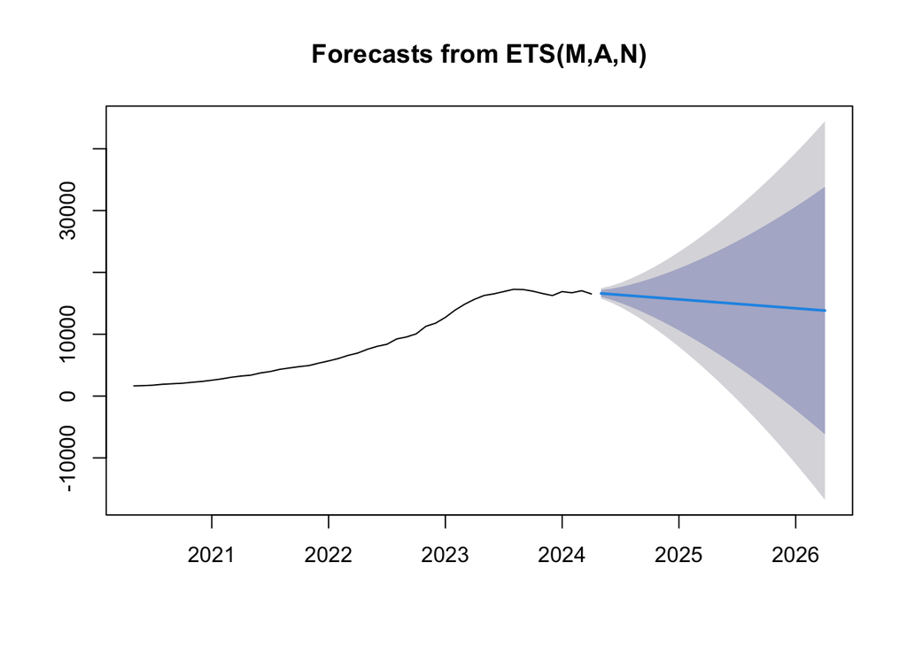

```r
plot(MA9_fc_2y)
```

- MA method says that the value will keep decrease for the next 2 years as well.
- Rank : 1.MA / 2. Simple smoothinig / 3. HW / 4. Naive